# Assignment 5

Lufei Wang

5/8/2019

## Summary Information

This dataset features shootings that happened in the USA during 2018 ([Mass Shooting Data](http://www.shootingtracker.com/)). The data reveals that 340 shootings occured and 373 lives were lost in USA in 2018. The most impacted city was Chicago since it had the highest number of shootings occurred. In addition, the states that had the highest number of shootings were California, Illinois. One of the worst shootings happened on February 14, 2018. This shooting caused the highest casuality in the USA during 2018.

## Summary Table

Here are the states where **shooting occured** in 2018 and the total number of people killed and injured in each state. The state is sorted by number of killed with higher numnber of killed shown first.

| State | Total Killed | Total Injured |
| --- | --- | --- |
| California | 50 | 136 |
| Florida | 48 | 132 |
| Pennsylvania | 35 | 63 |
| Texas | 29 | 62 |
| Illinois | 21 | 150 |
| Tennessee | 19 | 68 |
| Louisiana | 15 | 50 |
| North Carolina | 14 | 37 |
| Maryland | 13 | 31 |
| Ohio | 13 | 46 |
| Alabama | 12 | 55 |
| Missouri | 12 | 52 |
| Indiana | 10 | 27 |
| Michigan | 10 | 28 |
| Colorado | 9 | 27 |
| Arkansas | 7 | 17 |
| Kentucky | 7 | 25 |
| Delaware | 5 | 0 |
| New Mexico | 5 | 4 |
| New York | 5 | 53 |
| South Carolina | 5 | 19 |
| Arizona | 4 | 5 |
| New Jersey | 4 | 54 |
| Washington | 4 | 9 |
| Georgia | 3 | 33 |
| Nevada | 3 | 15 |
| District of Columbia | 2 | 23 |
| Oklahoma | 2 | 19 |
| Virginia | 2 | 17 |
| Kansas | 1 | 11 |
| Minnesota | 1 | 14 |
| Mississippi | 1 | 17 |
| Nebraska | 1 | 16 |
| Wisconsin | 1 | 16 |
| Connecticut | 0 | 8 |
| Massachusetts | 0 | 4 |
| Utah | 0 | 4 |

Insights: California has the highest number of killed since it is the first row in the table. Some states do not have shooting informations in 2018. Connecticut, Massachusetts, and Utah state do not have people killed during the shootings.

## Here Is A Participant Incident in Seattle (Skyway)

On April 29, 2018, an incident happened at 12603 Renton Ave S in Seattle (Skyway). 2 people were killed. In addtion, 2 people were injured, and the total casualty number is 4. According to the [report](https://www.seattletimes.com/seattle-news/crime/two-men-killed-in-skyway-shooting-identified/) from The Seattle Time, the shooting occurred in a parking lot shared by the Skyway VFW Clib and Tha Family Motorcycle Club about 4am. The article also mentioned that the parking lot is the frequent site of after-hours parties.

## An interactive map for shootings in 2018

To identify geographic locations where shootings happened, here is a interactive map (The sizes of the makers compare the casualty numbers. The bigger the markers, the higher casualty that caused):

[interactive chart not shown]

Two insights: *East Coast has highter shooting rate than the west coast.* The worst shooting happened in Pompano Beach (Parkland) where 17 people were killed.

## A plot To Show 10 States That Have The Highest Number of People Killed and Injured

Here is a plot that uses a horizontal bar chart to show the top 10 states that have the highest number of people killed and injured. This plot answers question about what ten states have the highest casualty among states in the US.

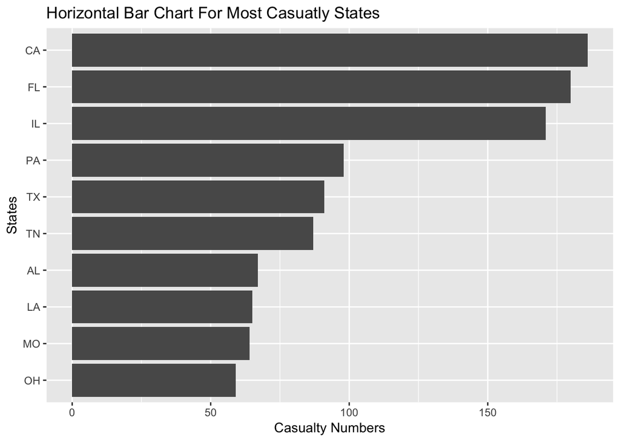

I chose horizontal bar chart because it’s a useful layout for comparing differences and making labels more legible.